# Final Project - Neural Networks & Deep Learning

## Loss Results Analysis

##### We see here a demonstration of the strong ability of the model to learn from the dataset. Indeed, starting from a high initial loss of 475.98 in Epoch 1, it improves to the point that it reaches 52.35 by Epoch 24. This drop of 89% in total training loss is proof of successful convergence.

##### The individual step losses decreased from above 3.0 to below 0.5 on in a quite consistant maner. It shows lower errors as well as more stable predictions accross batches.

##### This training behavior suggests the model's architecture (CNN encoder + attention-based LSTM decoder) is quite well-suited to the image captioning task. Furthermore, we can affirm that the preprocessing steps such as the tokenisation, the padding and the transformation were correctly implemented.

```python
# generate captions carefully
def generate_caption_attention(image_tensor, max_len=20):
    encoder.eval()
    decoder.eval()
    with torch.no_grad():
        image_tensor = image_tensor.unsqueeze(0).to(device)
        # extract features from image using CNN encoder
        encoder_out = encoder(image_tensor)  # (1, 196, 512)
        h = torch.zeros(1, 512).to(device)
        c = torch.zeros(1, 512).to(device)

        caption = []
        alphas = []

        word = torch.tensor([word2idx["<START>"]]).to(device)
        for _ in range(max_len):
            embedding = decoder.embed(word).squeeze(0)  # (256,)
            context, alpha = decoder.attention(encoder_out, h)  # (1, 512), (1, 196)
            lstm_input = torch.cat([embedding, context.squeeze(0)], dim=0).unsqueeze(0)
            h, c = decoder.lstm(lstm_input, (h, c))
            output = decoder.fc(h)
            predicted = output.argmax(1)
            word = predicted
            alphas.append(alpha.view(14, 14).cpu().numpy())
            predicted_word = idx2word[word.item()]
            if predicted_word == "<END>":
                break
            caption.append(predicted_word)
        caption = ' '.join(caption)
        return caption, alphas
```

### Evaluation score BLEU

##### Bleu is a metric which evaluates and compared generated texts

```python
from nltk.translate.bleu_score import sentence_bleu, SmoothingFunction

def evaluate_caption_attention(img_id):
    image = transform(Image.open(os.path.join(image_dir, img_id)).convert("RGB"))
    image_tensor = image.to(device)
    generated,_ = generate_caption_attention(image_tensor)

    references = [cap.lower().strip().split() for cap in captions[img_id]]
    candidate = generated.strip().split()
    bleu = sentence_bleu(references, candidate, smoothing_function=SmoothingFunction().method4)
    return bleu, generated
```

```python
#eval for ten images
total_bleu = 0
print(" BLEU score avec attention :\n")

for i, img_id in enumerate(selected_imgs[:10]):
    bleu, generated = evaluate_caption_attention(img_id)
    total_bleu += bleu
    print(f"{i+1}.  {img_id}")
    print(f"    Caption générée : {generated}")
    print(f"    BLEU score     : {bleu:.4f}\n")

print(f" Score BLEU moyen (attention) : {total_bleu / 10:.4f}")
```

```
 BLEU score avec attention :

1.  2479652566_8f9fac8af5.jpg
    Caption générée : a girl is climbing a rock wall
    BLEU score     : 0.0974

2.  102351840_323e3de834.jpg
    Caption générée : a man and a dog stand atop a black <UNK> mountain range
    BLEU score     : 0.0528

3.  278559394_b23af734b9.jpg
    Caption générée : a man and a woman are walking past a stained glass window
    BLEU score     : 0.1259

4.  3464708890_3cab754998.jpg
    Caption générée : a man in a blue shirt and shorts is standing on a red blanket with a blue blanket in a
    BLEU score     : 0.0627

5.  3424927725_c4d1fcfac3.jpg
    Caption générée : a man in blue rock climbing
    BLEU score     : 0.1290

6.  2869491449_1041485a6b.jpg
    Caption générée : two brown dogs are biting on a black frisbee
    BLEU score     : 0.0945

7.  3042679440_010b2c596c.jpg
    Caption générée : a group of people are in front of a store walking across a crosswalk
    BLEU score     : 0.1369

8.  507758961_e63ca126cc.jpg
    Caption générée : a dog and a goat chase two kids playing soccer
    BLEU score     : 0.0279

9.  247691240_3881777ab8.jpg
    Caption générée : a group of people pulling on a rope
    BLEU score     : 0.0340

10.  2260560631_09093be4c6.jpg
    Caption générée : a man in a yellow helmet climbs up a rock cliff
    BLEU score     : 0.0617

 Score BLEU moyen (attention) : 0.0823
```

## Analysis of BLEU results

### To go further

##### The modest score of 0.0823 due to the size of the dataset could be ameliorated in specific conditions. Indeed, key visual elements such as people, clothing and actions are well detected, which are relevant spatial features.

##### This means that training on larger dataset for example could be an idea to ameliorate improve the performance. What can also be done is to use transformer-based decoders to obtain different results with probably a richer modeling. Beam search could be a good option as well.

### Potential use cases

##### Even if the performance of our model is modest, it still has interesting model to uses case such as creating automatic descriptions for social media, news agencies or for personal photo organization for example.

#### Distribution of the BLEU results

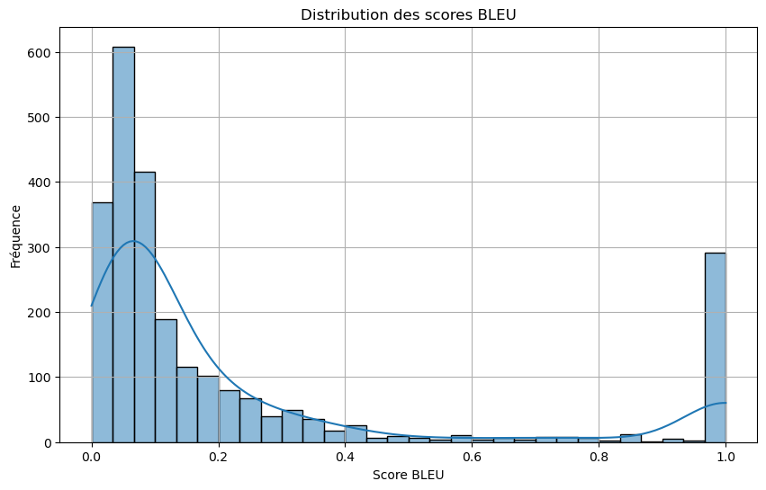

```python
# see if there is overfitting
total_bleu = []
for i, img_id in enumerate(selected_imgs):
    bleu, generated = evaluate_caption_attention(img_id)
    total_bleu.append(bleu)

plt.figure(figsize=(10, 6))
sns.histplot(total_bleu, bins=30, kde=True)
plt.title("Distribution des scores BLEU")
plt.xlabel("Score BLEU")
plt.ylabel("Fréquence")
plt.grid()
plt.show()
```

## Heatmap of Attention

```python
def visualize_attention(img_path, caption, alphas):
    image = Image.open(img_path).convert("RGB")
    image = image.resize((256, 256))
    fig = plt.figure(figsize=(15, 10))
    for t in range(len(caption)):
        ax = fig.add_subplot(2, (len(caption)+1)//2, t+1)
        ax.set_title(caption[t])
        alpha = alphas[t]
        alpha = Image.fromarray((alpha * 255).astype('uint8')).resize((256, 256), Image.BICUBIC)
        alpha = transforms.ToTensor()(alpha)

        ax.imshow(image)
        ax.imshow(alpha.squeeze(), alpha=0.6, cmap='jet')
        ax.axis("off")

    plt.tight_layout()
    plt.show()
```

```
 Caption générée : two little boys in tuxedos
```

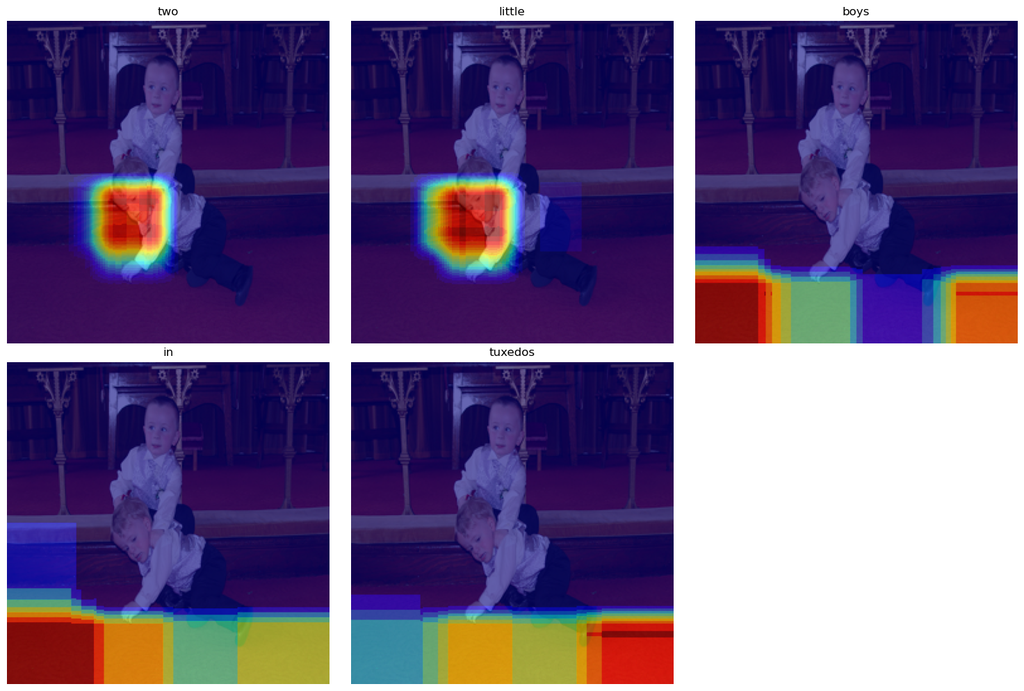

```python
img_id = selected_imgs[25]
img_path = os.path.join(image_dir, img_id)
image_tensor = transform(Image.open(img_path).convert("RGB")).to(device)

caption, alphas = generate_caption_attention(image_tensor)
print(" Caption générée :", caption)
visualize_attention(img_path, caption.split(" "), alphas)
```

# Conclusion

#### Our project highlights the potention of models which are attention-based and that are for alining vision and language.